# alberto_implementation

Niek Brouwer

2023-02-08

In this document we apply the method developed by Gil-Jimenez et al. to the METABRIC breast cancer cohort. The spatial coordinates and phenotype classification of single cells is retrieved from the paper by Danenberg et al. (2022).

```r
# invisible(lapply(paste0('package:', names(sessionInfo()$otherPkgs)), detach, character.only=TRUE, unload=TRUE))

library(here)
library(fst)
library(data.table)
library(ggplot2)
library(assertthat)
source(here("UtilityFunctions.R"))
library(tictoc)

cells <- getCells()
phenotype_list <- get_phenotypes()

library(tidyverse)
library(ggpubr)
library(readxl)
library(reshape2)
library(dbscan)
library(broom)
library(zoo)
library(knitr)
library(NMF,quietly = T)
library(MASS)
library(car)
library(doParallel)
library(foreach)
library(spatstat)
# library(raster)
library(gridExtra)
```

```r
# Unregister open clusters
unregister_dopar <- function() {
  env <- foreach:::.foreachGlobals
  rm(list=ls(name=env), pos=env)
}

unregister_dopar()
```

## 1-NN distance computation

Alberto uses two input files: * A cell dataframe with columns: “tnumber’,”analysisregion”, “layer”, “Xmin”, “Xmax”, “Ymin”, “Ymax”, “Xcenter”, “Ycenter”, “phenotype”, “cellarea” * A tissue area dataframe with columns:“tnumber’,”Tumor.Area.mm2”, “Stroma.Area.mm2”, “Total.Area”

We miss some of this information. We only have cell centroid coordinates and we don’t have tissue area.

```r
# Rename labels to fit methods of Alberto
cells <- cells %>% rename(tnumber = ImageNumber)
cells <- cells %>% rename(phenotype = meta_description)
cells <- cells %>% rename(Xcenter = Location_Center_X)
cells <- cells %>% rename(Ycenter = Location_Center_Y)

# Remove unncessary attributes
cells <- cells[,c("tnumber", "ObjectNumber", "Xcenter", "Ycenter", "phenotype", "AreaShape_Area")]

#To take a small subset (debugging purposes):
# cells <- cells[cells$tnumber %in% seq(1,10)]
```

Compute all 1-NN distances.

```r
tic('1-NN distances')
# call cores (parallelization)
# Comment this because of limitation on core usability in darwin
cores=detectCores()
cl <- makeCluster(floor(cores[1]/4))
registerDoParallel(cl)

# First NNdist all-against-all phenotypes
#' @param x Multiplex immunofluorescence coordinate dataframe (with Xcenter, Ycenter, phenotype, etc)
#' @param phenotype1 Phenotype From
#' @param phenotype2 Phenotype To
distances <- function(x, phenotype1,phenotype2) {
  # Create a point pattern
  spdat <- ppp(
    x = x$Xcenter,
    y = x$Ycenter,
    window = owin(
      xrange = c(min(x$Xcenter), max(x$Xcenter)),
      yrange = c(min(x$Ycenter), max(x$Ycenter))
    ),
    marks = x$phenotype
  )
  phenos <- unique(x$phenotype)

  #if phenotypes to compare are equal, then the 2nd nearest neighbour must be used, else the current point is compared to itself
  if(phenotype1 != phenotype2){
    res <- nncross(spdat[which(spdat$marks == phenotype1)], spdat[which(spdat$marks == phenotype2)], k = 1, what = 'dist')
  } else {
    res <- nncross(spdat[which(spdat$marks == phenotype1)], spdat[which(spdat$marks == phenotype2)], k = 2, what = 'dist')

  }
  return(res)
}

# Define which phenotypes will be studied (UNIQUE CELL TYPES IN YOUR DATASET)
# phenotypes <- unique(cells$phenotype) #All cell types
phenotypes <- unique(phenotype_list$stromal_immune$pg_id_map$meta_description)[1] #Take only 1 for debugging
message(paste0("The phenotypes we are considering: ", paste(phenotypes,collapse = ', ')))
```

```
## The phenotypes we are considering: CD8^{+} T cells
```

```r
# Compute 1-NN for all combinations of samples (n=24) x phenotype FROM (n=7) x phenotype TO (n=7)
spatresall <-
  foreach(i = unique(cells %>% pull(tnumber)),
          .packages = c('sp', 'spatstat'),
          .final = function(x) setNames(x, unique(cells %>% pull(tnumber)))) %dopar% {
            x <- cells[which(cells$tnumber == i),]
            phenotypes <- setNames(phenotypes, phenotypes)
            spres <-
              lapply(phenotypes, function(p1) {
                lapply(phenotypes, function(p2) {
                  distances(x, p1, p2)
                })
              })
            return(spres)
          }

stopCluster(cl)

toc()
```

```
## 1-NN distances: 7.935 sec elapsed
```

Clean-up.

```r
#Reshape hot mess of lists of lists of lists into long data frame.
dfl <- lapply(spatresall, function(tnr){
  lapply(tnr, function(p1){
    rbindlist(lapply(p1,function(Distance) {
      as.data.frame(Distance)
    }), idcol = "phenotype_to")
  })
})

dfl2 <- lapply(dfl, function(tnr){
  rbindlist(tnr, idcol = "phenotype_from")
})

dfl3 <- rbindlist(dfl2, idcol = "tnumber")

#add pseudocounts on distances for log transform
#1 pixel = 1 micron
dfl3$Distance <- (dfl3$Distance + 1)

NNdistances <- dfl3

# free up some memory. these temps are no longer needed
rm(dfl)
rm(dfl2)
rm(dfl3)
gc() # do garbage collection to free up memory
```

```
##            used  (Mb) gc trigger  (Mb) max used  (Mb)
## Ncells  3077988 164.4    5977781 319.3  5977781 319.3
## Vcells 13768844 105.1   90917148 693.7 78775909 601.1
```

### Boxplot of distances

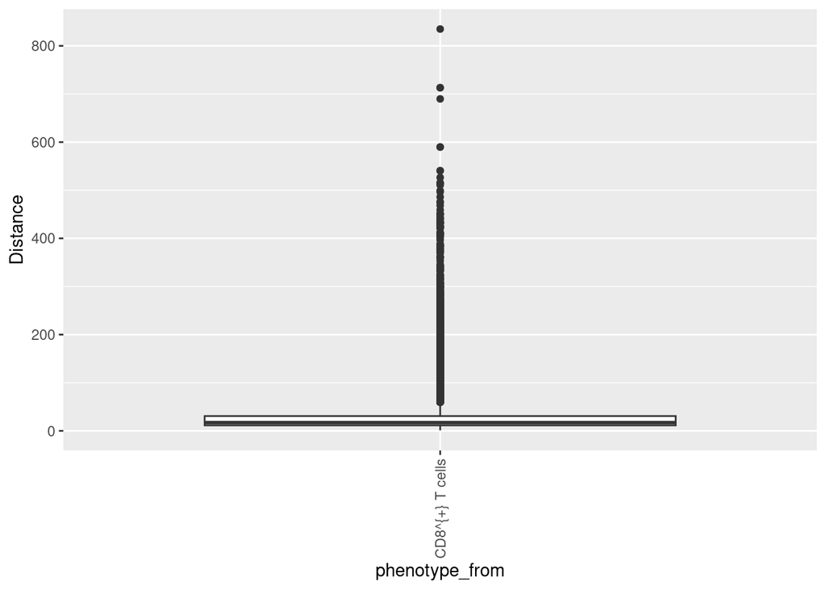

```r
ggplot(NNdistances, aes(x=phenotype_from, y=Distance)) +
    geom_boxplot() + theme(axis.text.x = element_text(angle = 90, vjust = 0.5, hjust=1))
```

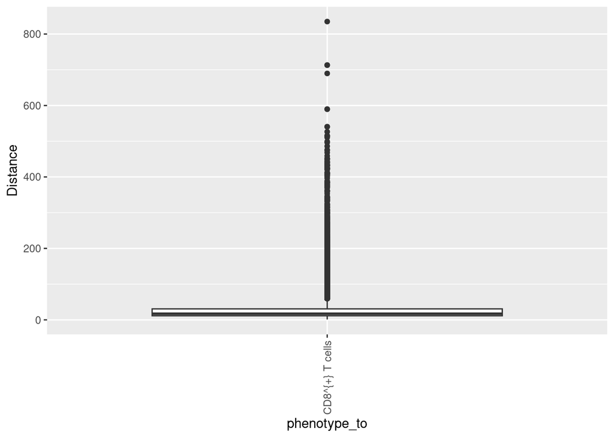

```r
ggplot(NNdistances, aes(x=phenotype_to, y=Distance)) +
    geom_boxplot() + theme(axis.text.x = element_text(angle = 90, vjust = 0.5, hjust=1))
```

Estimate 1-NN distance distribution by grouping distances in bins.

```r
options(dplyr.summarise.inform = FALSE)

tic('bin smoothing')
# Explore data from 0 to 300 microns
SlidingBins_300 <- rollapply(c(0:300),5,function(y) { return(c(min(y),max(y)))})

CountRows <- function(x) {
  cnt <- apply(SlidingBins_300,1, function(y) {nrow(x[which(x$Distance >= y[1] & x$Distance <= y[2])])})
  return(cnt)
}

BinCounts_300 <- apply(SlidingBins_300, 1, function(x) {
  CurrentWindow <- subset(NNdistances, Distance >= x[1] & Distance <= x[2])
  GroupCounts <- CurrentWindow %>% group_by(tnumber, phenotype_from, phenotype_to) %>%
    dplyr::summarise(N = dplyr::n())
  return(GroupCounts)
})

names(BinCounts_300) <- c(1:297)
dfslides_300 <- as.data.frame.matrix(SlidingBins_300)
dfslides_300$V3 <- apply(dfslides_300,1,mean)
dfslides_300$ID <- row.names(dfslides_300)

LongBinCounts_300 <- bind_rows(BinCounts_300, .id = "nth_window")
# WinMean is the X coordinate of your "calculated histogram"
LongBinCounts_300$WinMean <- dfslides_300$V3[match(LongBinCounts_300$nth_window, dfslides_300$ID)]

# We don't have total areas, sum all cell areas or take max and min x and y coordinate?
areas <- left_join(aggregate(Xcenter ~ tnumber, cells, function(x) min(x)),
                   aggregate(Xcenter ~ tnumber, cells, function(x) max(x)), by='tnumber')
areas <- left_join(areas,aggregate(Ycenter ~ tnumber, cells, function(x) min(x)), by='tnumber')
areas <- left_join(areas,aggregate(Ycenter ~ tnumber, cells, function(x) max(x)), by='tnumber')
areas$area <- (areas[,3]-areas[,2])*(areas[,5]-areas[,4])*0.001 #area in mm

# Match total areas of the tissue
LongBinCounts_300$tnumber <- as.integer(LongBinCounts_300$tnumber)
LongBinCounts_300$Area <- LongBinCounts_300 %>%
  left_join(data.frame(areas), by='tnumber') %>%
  mutate(Area=area) %>% pull(Area)

# N.per.mm2 is the Y coordinate of your "calculated histogram"
# It's normalized for area
LongBinCounts_300$N.per.mm2 <- LongBinCounts_300$N / LongBinCounts_300$Area

# Function to compute Area under the curve
funAUC <- function(x,y){
  id <- order(x)
  AUC <- sum(diff(x[id]) * rollmean(y[id],2))
  return(AUC)
}

AUCScaledSlides_300 <- LongBinCounts_300 %>%
  dplyr::group_by(phenotype_from, phenotype_to, tnumber) %>%
  dplyr::mutate(N.per.mm2.scaled = N.per.mm2 / funAUC(WinMean, N.per.mm2))

stopifnot(!(Inf %in% AUCScaledSlides_300$N.per.mm2.scaled))

# Sometimes there are INf values here
# How to solve this?
# Remove or make 1?
# AUCScaledSlides_300 <- AUCScaledSlides_300[!is.infinite(AUCScaledSlides_300$N.per.mm2.scaled),]

#double check if the AUC of AUCs is 1
AUCcheck <- AUCScaledSlides_300 %>%
  dplyr::group_by(phenotype_from, phenotype_to, tnumber) %>%
  dplyr::mutate(AUC = funAUC(WinMean, N.per.mm2.scaled))
stopifnot(length(unique(lapply(unique(AUCcheck$AUC), round)))==1)

#save this
write_delim(AUCScaledSlides_300 %>%
              mutate(phenotype_combo=paste(phenotype_from,phenotype_to,sep='_to_')), paste(here('scratch/AUCScaledSlides_300'), '.tsv', sep=''),delim='\t')

toc()
```

```
## bin smoothing: 10.82 sec elapsed
```

## Parameter estimation

From the distance bin collection, we try to estimate a distribution.

```r
invisible(lapply(paste0('package:', names(sessionInfo()$otherPkgs)), detach, character.only=TRUE, unload=TRUE))

library(ComplexHeatmap)
library(tidyverse)
library(plyr)
library(cold) #function fixeff()
library(lme4)
library(glmmTMB)
library(fitdistrplus)
library(tidyr)
library(cold)
library(broom)
library(ggpubr) # stat_compare_means
library(here)
library(fst)
library(doParallel)

library(data.table)
library(ggplot2)
library(assertthat)
library(tictoc)
source(here("UtilityFunctions.R"))
```

```r
tic('parameter initialization')
all_distances_data <- read_delim(here('scratch/AUCScaledSlides_300.tsv'),delim='\t',
                                 col_types=list(tumor_stroma=col_character()))
```

```r
all_distances_data <- all_distances_data %>% as_tibble %>%
  mutate(distance_window = WinMean) %>%
  mutate(phenotype_combo = paste(phenotype_from, phenotype_to, sep='_to_')) %>%
  dplyr::select(tnumber, phenotype_combo, `N.per.mm2.scaled`, distance_window) %>%
  mutate(new = `N.per.mm2.scaled` * 1000) %>%
  mutate(new =round(new))

# Recreate 1-NN histogram from coordinates (this is required for function "fitdistrplus")
all_combos_dists <- tibble()
for(tn in unique(all_distances_data %>% pull(tnumber))){
  for(combo in unique(all_distances_data %>% pull(phenotype_combo))){
    all_dists_tnum <- list()

    dists <- c(1,all_distances_data %>% filter(tnumber == tn) %>% filter(phenotype_combo == combo) %>% pull(distance_window) )
    times <- c(1, all_distances_data %>% filter(tnumber == tn) %>% filter(phenotype_combo == combo) %>% pull(new))

    if(length(times) == 0){
      dists <- c(1:298)
      times <- rep(0,length(c(1:298)))
    }
    for(i in 1:length(times)){
      all_dists_tnum <- c(all_dists_tnum, rep(dists[i], times[i]))
    }
    aldists <- unlist(all_dists_tnum %>% as.numeric)
    aldistsdf <- as_tibble(data.frame(dists = aldists,
                                      tnumber = rep(tn, length(aldists)),
                                      combo = rep(combo, length(aldists))))
    all_combos_dists <- bind_rows(all_combos_dists, aldistsdf)
  }

}

# # Takes a long time, do this in parallel?
# # Recreate 1-NN histogram from coordinates (this is required for function "fitdistrplus")
# cores=detectCores()
# cl <- makeCluster(floor(cores[1]/4)) #not to overload your computer
# registerDoParallel(cl)
#
# all_combos_dists <- foreach(tn = unique(all_distances_data %>% pull(tnumber)), .combine=rbind, .packages="tidyverse") %dopar% {
#   for(combo in unique(all_distances_data %>% pull(phenotype_combo))){
#     all_dists_tnum <- list()
#     dists <- c(1,all_distances_data %>% filter(tnumber == tn) %>% filter(phenotype_combo == combo) %>% pull(distance_window) )
#     times <- c(1, all_distances_data %>% filter(tnumber == tn) %>% filter(phenotype_combo == combo) %>% pull(new))
#
#     if(length(times) == 0){
#       dists <- c(1:298)
#       times <- rep(0,length(c(1:298)))
#     }
#
#     for(i in 1:length(times)){
#       all_dists_tnum <- c(all_dists_tnum, rep(dists[i], times[i]))
#     }
#
#     aldists <- unlist(all_dists_tnum %>% as.numeric)
#     aldistsdf <- as_tibble(data.frame(dists = aldists,
#                                       tnumber = rep(tn, length(aldists)),
#                                       combo = rep(combo, length(aldists))))
#
#   }
#   aldistsdf
# }
#
# stopCluster(cl)

# Fit a Weibull distribution by Maximum likelihood (this is an initial estimation)
initial_params <- data.frame(matrix(ncol=5, nrow=0))
colnames(initial_params) <- c('term','estimate','std.error', 'tnumber','combo')
initial_params <- initial_params %>%
  mutate(term=as.character(term), estimate=as.numeric(estimate), `std.error`=as.numeric(`std.error`),tnumber=as.numeric(tnumber),
         combo=as.character(combo))


for(combo in unique(all_distances_data %>%  pull(phenotype_combo))){
  # for different "tnumber"
  message(combo)

  for(tn in unique(all_combos_dists  %>% pull(tnumber))){
        # take into account only 1-NN dists < 100, because of the precision of fitdists (no of bins in histogram)
    # EXCEPT for From/To PanCK or negative
    # the parameters will be further optimized later

  # There are some instances that have only 1 occurence or where the parameters cannot be estimated,
  # We probably need more filtering earlier
    tryCatch({
    if(str_detect(combo, 'PanCK\\+_') | str_detect(combo, 'negative_')){
      params <- fitdist(all_combos_dists %>%
                          filter(combo == combo) %>% filter(tnumber == tn)  %>%
                          pull(dists) ,"weibull") %>% summary
    } else{
      params <- fitdist(all_combos_dists %>%
                          filter(combo == combo) %>% filter(tnumber == tn) %>% filter(dists < 100) %>%
                          pull(dists) ,"weibull") %>% summary
    }
    class(params) <- c("fitdist", "fitdistr")
    params <- broom::tidy(params)
    params <- params %>% mutate(tnumber=rep(tn,nrow(params))) %>%
      mutate(combo=rep(combo,nrow(params)))

    initial_params <- bind_rows(initial_params, params)
    }, error=function(e){})
  }
}
```

```
## CD8^{+} T cells_to_CD8^{+} T cells
```

```r
initial_params_weib <- initial_params

write_delim(initial_params_weib, here('scratch/initial_params_weib_stromalImmune.tsv'),delim='\t')

toc()
```

```
## parameter initialization: 50.036 sec elapsed
```

## Fitting NLME model

Now we fit a Weibull function using a nonlinear-mixed fixed effect model to the 1-NN distance distribution.

```r
invisible(lapply(paste0('package:', names(sessionInfo()$otherPkgs)), detach, character.only=TRUE, unload=TRUE))
library(tidyverse)
library(ggpubr)
library(readxl)
library(reshape2)
library(dbscan)
library(broom)
library(zoo)
library(knitr)
library(magrittr)
library(NMF,quietly = T)
library(MASS)
library(car)
library(doParallel)
library(stats)
library(foreach)
library(spatstat)
# library(raster)
library(nlme)
library(dplyr)
library(gridExtra)
library(here)
library(tictoc)
```

```r
initial_params <- read_delim(here('scratch/initial_params_weib_stromalImmune.tsv'),delim='\t')
# Calculate number of cells for each cell type / sample (will be used later for filtering purposes)
n_cells <- aggregate(cells$phenotype, by=list(cells$tnumber,cells$phenotype), FUN=length)
colnames(n_cells) <- c('tnumber', 'phenotype', 'n')

xy_data_exc_oct <- read_delim(here('scratch/AUCScaledSlides_300.tsv'),delim='\t') %>%
  mutate(distance_window = WinMean) %>%
  mutate(x=distance_window, y=`N.per.mm2.scaled`)
threshold_pixels <- 300
threshold_microns <- threshold_pixels

# Define maximum Shape (A_max) and maximum Scale (B_max) parameters for your fits
B_max <- 500 # max scale parameter (0,500]
A_max <- 10  # max shape parameter (0,10]

# Define Weibull and parameterized Weibull functions, and functions to convert between parameterized and
## non parameterized Weibull
## (Parameterization was done to ease the fitting procedure, in a non-restricted manner)
convert_params <- function(a,b){
  A=-log(A_max/a - 1)
  A = as.numeric(A)
  B=-log(B_max/b-1)
  B = as.numeric(B)
  return(c(A=A,B=B))
}

convert_params_reverse <- function(A,B){
  a=A_max/(1+exp(-A))
  b=B_max/(1+exp(-B))
  return(c(a=a,b=b))
}
# Define Weibull distribution function in a parameterized way:
nform2 <- ~(( ( A_max/(1+exp(-A)) )  / ( B_max/(1+exp(-B)) )) * (( x/( B_max/(1+exp(-B))) )^(( A_max/(1+exp(-A)) )-1)) * exp(-1* (x/( B_max/(1+exp(-B))))^( A_max/(1+exp(-A)) )))

weibfunc2 <- function(x,A,B){
  a = A_max/(1+exp(-A))
  b = B_max/(1+exp(-B))
  return(((a/b) * ((x/b)^(a-1)) * exp(- (x/b)^a)))
}

nfun2 <- deriv(nform2,namevec=c("A","B"),
               function.arg=c("x","A","B"))
```

```r
# Define function to fit a Weibull model to x/y coordinates of normalized 1-NN distance
## distribution coordinates, filtering out samples with n_cells < threshold_filter_cells
#' @param xy_coordinates_curves 1-NN distribution coordinate dataframe
#' @param combi Cell combination of interest: 'CellFROM_to_CellTO'
#' @param n_cells_df Dataframe with number of cells per sample (for each cell type)
#' @param threshold_filter_cells Threshold to filter out samples depending on the cell number
#' @param initial_params_df Dataframe with initial Weibull parameters
fit_data <- function(xy_coordinates_curves, combi, n_cells_df, threshold_filter_cells,
                     initial_params_df){
  message(combi)
  xy_data_filt <- xy_coordinates_curves %>% filter(phenotype_combo == combi) %>% as_tibble

  xy_data_filt <- xy_data_filt %>%
    left_join(n_cells_df %>% mutate(n_from=n) %>% dplyr::select(-n), by=c('tnumber','phenotype_from'='phenotype')) %>%
    left_join(n_cells_df %>% mutate(n_to=n) %>% dplyr::select(-n), by=c('tnumber','phenotype_to'='phenotype'))

  threshold_cells <- threshold_filter_cells
  message(xy_data_filt %>% filter(n_from<=threshold_cells & n_to <= threshold_cells) %>%
            mutate(tnumber=paste(tnumber, 'nFROM', as.character(n_from), 'nTO',as.character(n_to))) %>%
            pull(tnumber) %>% unique %>% paste(collapse=' / '))

  xy_data_filt <- xy_data_filt %>% filter(n_from>threshold_cells & n_to > threshold_cells)

  # Add missing observations in data and set to 0
  ## i.e. if no distances were observed beyond 100 microns, the normalized scaled counts
  ## from 100 to 300 microns will be set to 0
  # include 0,0 or only 1,0??
  xy_data_filt <- expand.grid(x=c(1,xy_data_filt %>%pull(distance_window) %>% unique),
                              tnumber=xy_data_filt %>%pull(tnumber) %>% unique,
                              phenotype_combo=combi) %>%
    left_join(xy_data_filt, by=c('x','tnumber', 'phenotype_combo')) %>%
    mutate(y=ifelse(is.na(y),0,y))

  mean_params <- initial_params_df %>% filter(combo == combi) %>%
    filter(tnumber %in% unique(xy_data_filt$tnumber)) %>%
    group_by(term) %>% dplyr::summarise(mean_estimate = mean(estimate))

  start_params <- c(a=mean_params %>% filter(term == 'shape') %>% pull(mean_estimate),
                    b=mean_params %>% filter(term == 'scale') %>% pull(mean_estimate))

  if(combi == 'PanCK+_to_PanCK+'){
    start_params <- c(a=3, b=10) # rewrite exception imsicion for pck-pck
  }

  fit52_oct <- tryCatch({
    nlme(y~nfun2(x,A,B),
         fixed=A+B~1,
         random=list(tnumber=pdDiag(A+B~1)), # or pdDiag, pdLogChol
         data=xy_data_filt %>% mutate(tnumber = factor(tnumber)),
         start=convert_params(start_params['a'], start_params['b']),
         method='REML', control = nlmeControl(maxIter = 1000,
                                              returnObject = F,
                                              msMaxIter=200,
                                              pnlsTol=1e-1,
                                              tolerance=1e-6, opt="nlm"))
  },
  error=function(cond){
    message(paste('failed',combi))
    return(combi)
  })
  # }
  return(list(model=fit52_oct, xy_data=xy_data_filt))

}
```

# Implement pipeline

- First try to fit models for ALL data
- If for a particular phenotype combo it doesn’t work, fit:
- Fit all data with n_cells > 20
- If not, increase the threshold from 20 to 100

```r
tic('Weibull parameter estimation')
# Define phenotype combinations to study in data
combinations_to_study <- unique(xy_data_exc_oct %>% pull(phenotype_combo))

success_models <- list() # Fitted models

# Dataframe to store fitted Weibull coefficients
weib_coefs <- data.frame(matrix(nrow=0,ncol=4))
colnames(weib_coefs) <- c('a','b','sample','phenotype_combo')
weib_coefs$a %<>% as.numeric()  # shape
weib_coefs$b %<>% as.numeric()  # scale
weib_coefs$sample %<>% as.character()
weib_coefs$phenotype_combo %<>% as.character()

# Function to store x/y coordinates used for modelling
xy_data_weib <- xy_data_exc_oct %>% slice(0)
xy_data_weib <- xy_data_weib %>% add_column(yhat=as.numeric())

# Function to iterate through pheno combos
subset_combinations <- combinations_to_study
# Iterate through different number of threshold minimum number of cells sample
## (in some cases, all samples word, in other strenghter filter need to be
## applied to samples with low number of cells)
for(threshold_cells in c(0,20,50,70,100)){
  model_objects <- list()
  if(length(subset_combinations) > 0){
    for(combi in subset_combinations){
      message(threshold_cells)
      # Fit Weibull distribution
      ## If fit succeeds, a nlme model is returned, otherwise a character
      ## with the name of the failed phenotype combination is returned
      pipeline_run <- fit_data(xy_data_exc_oct, combi, n_cells,
                               threshold_cells, initial_params)
      model_objects <- append(model_objects,
                              list(combi=pipeline_run[['model']]))
      fitted_model <- tail(model_objects, 1)[[1]] # retrieve fitted model in the for loop
      # If the model successfully fitted, append estimated parameters of the model
      # if(class(fitted_model)  != 'character'){
      if(!is(fitted_model, 'character')){
        # Weibull parameters:
        new_data_weib_param <- as_tibble(ranef(fitted_model)) %>%
          mutate(sample=rownames(ranef(fitted_model))) %>%
          mutate(A=A + fixef(fitted_model)['A'],
                 B=B+ fixef(fitted_model)['B']) %>%
          mutate(phenotype_combo=combi) %>%
          mutate(a=10/(1+exp(-A)),b=500/(1+exp(-B)))
        weib_coefs <- bind_rows(weib_coefs, new_data_weib_param)

        # x/y coordinates of input / output model:
        xy_data_weib <- bind_rows(xy_data_weib,
                                      pipeline_run[['xy_data']] %>% mutate(yhat=fitted(fitted_model)))
      }
    }
  }
  names(model_objects) <- subset_combinations
  # Update subset combinations. Include only phenotype combinations whose modelling failed
  subset_combinations <- names(model_objects)[lapply(model_objects, class) == 'character']

  # Update list of succesfully fitted models
  success_models <- append(success_models,
                           model_objects[lapply(model_objects, class) != 'character'])

}
```

```
## 0
```

```
## CD8^{+} T cells_to_CD8^{+} T cells
```

```
## failed CD8^{+} T cells_to_CD8^{+} T cells
```

```
## 20
```

```
## CD8^{+} T cells_to_CD8^{+} T cells
```

```
## 121 nFROM 1 nTO 1 / 130 nFROM 1 nTO 1 / 154 nFROM 1 nTO 1 / 177 nFROM 1 nTO 1 / 185 nFROM 1 nTO 1 / 186 nFROM 1 nTO 1 / 208 nFROM 1 nTO 1 / 247 nFROM 1 nTO 1 / 262 nFROM 1 nTO 1 / 267 nFROM 1 nTO 1 / 328 nFROM 1 nTO 1 / 339 nFROM 1 nTO 1 / 348 nFROM 1 nTO 1 / 354 nFROM 1 nTO 1 / 375 nFROM 1 nTO 1…
```

```r
toc()
```

```
## Weibull parameter estimation: 411.256 sec elapsed
```

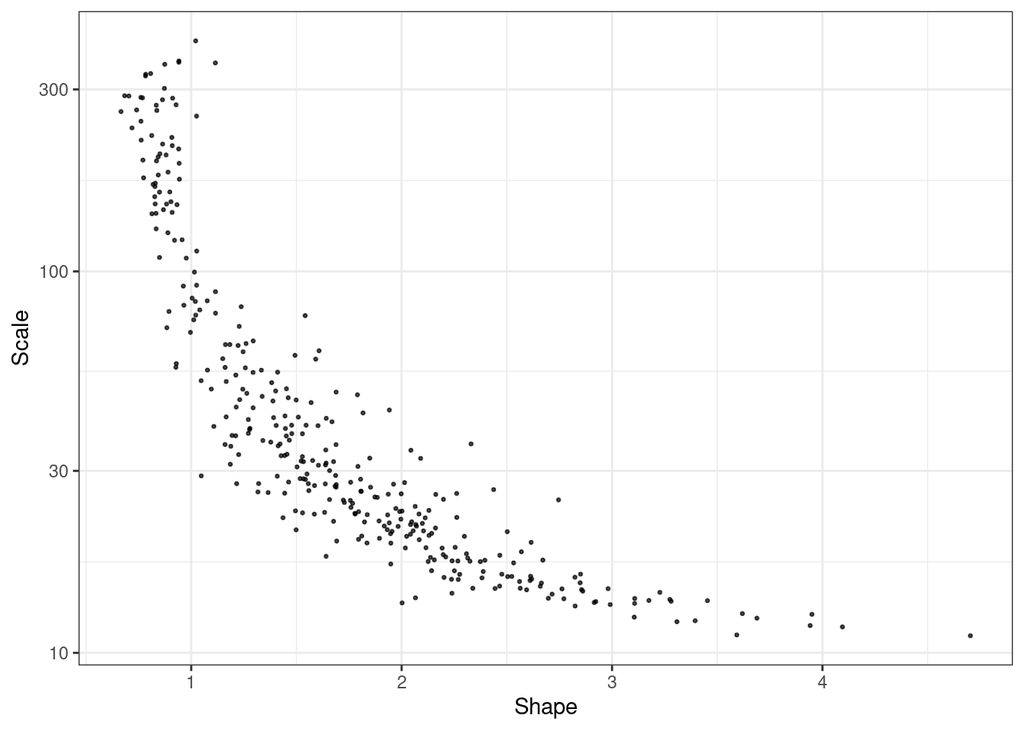

```r
# Process parameters
final_parameters <- data.frame()
for(combi in names(success_models)){
  fixefect <- fixef(success_models[[combi]])
  ranef <- ranef(success_models[[combi]])

  final_parameters <- final_parameters %>%
    bind_rows(  ranef %>%
                  mutate(tnumber= rownames(ranef),
                         phenotype_combo=combi) %>%
                  mutate(A = A + fixefect[['A']],
                         B = B + fixefect[['B']]) %>%
                  mutate(a=10/(1+exp(-A)),b=500/(1+exp(-B))))

}

final_parameters %>%
  # separate(phenotype_combo, into=c('phenotype_from','phenotype_to'),sep='_to_') %>%
  # mutate(phenotype_to=mapvalues(phenotype_to, from=c('CD20+','CD3+','CD3+FoxP3+',
  #                                                    'CD68+','CD8+CD3+','PanCK+'),
  #                               to=c('B-cell','T-helper','Treg','Macrophages','CD8 T-cell','Cancer cell'))) %>%
  # mutate(phenotype_from=mapvalues(phenotype_from, from=c('CD20+','CD3+','CD3+FoxP3+',
                                  #                        'CD68+','CD8+CD3+','PanCK+'),
                                  # to=c('B-cell','T-helper','Treg','Macrophages','CD8 T-cell','Cancer cell'))) %>%
  # mutate(phenotype_to=paste('to',phenotype_to)) %>%
  ggplot(aes(x=a, y=b)) +
  geom_point(alpha=0.7, size=0.5) +
  # geom_density_2d() +
  theme_bw() + scale_y_log10() +
  xlab('Shape') + ylab('Scale') + scale_color_brewer(palette='Set2') +
  theme(legend.position='right')
```

```r
ggsave(here('output/ShapeScaleScatterplot.png'))
```